# Data Analysis for Study 2

# Study 2 Introduction

This Markdown documents the process to analyze the data for Study 2 which looked at the impact of a warning at the begining of the experiment on the difference between the truncated and the control condition.

Data was collected on December 11th, 2017 by using Amazon’s Mechanical Turk for ditribution and Qualtrics as a survey platform.

This HTML was last knitted on: 2019-09-08 16:45:20

## Set Up

### Packages and Libraries

You must run this section before you can run any other chunks.

### Data Import

You must run this section before you can run any other chunks.

### Exclusions

You can exclude subjects who did not get the correct answer in the exercise by changing Exclude_Exercise_Check to TRUE. The next time you run all the code, these participants will be excluded.

For this report, **no** participants are being excluded from analysis.

## Methods

### Participants

| dem_gender | n |
| --- | --- |
| female | 50 |
| male | 58 |
| non-binary | 1 |

| mean_age | sd_age | median_age | min_age | max_age | range_age |
| --- | --- | --- | --- | --- | --- |
| 35.07339 | 11.18838 | 32 | 21 | 75 | 54 |

| dem_ed | n | percentage |
| --- | --- | --- |
| 1 | 1 | 0.9174312 |
| 2 | 15 | 13.7614679 |
| 3 | 27 | 24.7706422 |
| 4 | 2 | 1.8348624 |
| 5 | 9 | 8.2568807 |
| 6 | 49 | 44.9541284 |
| 7 | 2 | 1.8348624 |
| 8 | 4 | 3.6697248 |

59% of participants reported having at least a Bachelor’s degree. The sample also included a range of self-reported graph literacy.

| n | mean | sd | median | min | max | range | alpha |
| --- | --- | --- | --- | --- | --- | --- | --- |
| 109 | 44.45872 | 8.22995 | 45 | 21 | 60 | 39 | 0.89 |

### Power

Because we hypothesized that the truncation effect would be reduced with a warning, we determined our sample size a priori based on a power analysis predicting a small-to-medium effect size of 0.35, an alpha of 0.05, and power of 0.9, which estimated a required sample size of at least 88 participants.

### Exercise Check

13 did not get the manipulation check question right. Accuracy was 88.07%

For this report, **no** participants are being excluded from analysis. If you want to see results when participants who got the exercise wrong are excluded/included, you can go to the section called Exclusions (at the top of this file) and change Exclude_Exercise_Check <- TRUE

Excluding the participants who did not answer the training exercise correctly initially does not change the pattern or results or conclusions drawn.

## Results

### Truncation effect

| condition | n | mean | sd | median | min | max | range |
| --- | --- | --- | --- | --- | --- | --- | --- |
| control | 109 | 3.637156 | 0.5484576 | 3.6 | 2.55 | 5.70 | 3.15 |
| truncated | 109 | 4.279817 | 0.7849900 | 4.2 | 2.25 | 6.55 | 4.30 |

Average ratings for truncated graphs (M<sub>truncated</sub> = 4.28, SD<sub>truncated</sub> = 0.78) were higher than average ratings for control graphs (M<sub>control</sub> = 3.64, SD<sub>control</sub> = 0.55), as shown in Figure 3B.

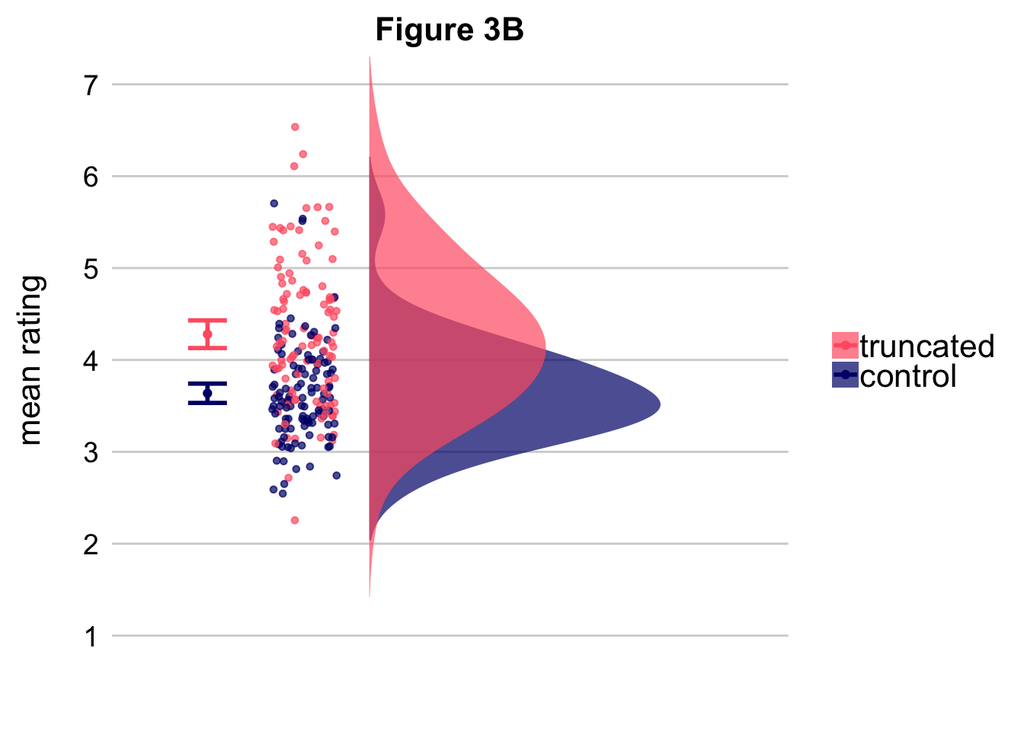

```
##
##  Paired t-test
##
## data:  subject_mean_rating by condition
## t = -10.643, df = 108, p-value < 0.00000000000000022
## alternative hypothesis: true difference in means is not equal to 0
## 95 percent confidence interval:
##  -0.7623462 -0.5229749
## sample estimates:
## mean of the differences
##              -0.6426606
```

```
##
## Cohen's d
##
## d estimate: -0.5439713 (medium)
## 95 percent confidence interval:
##      lower      upper
## -0.8158510 -0.2720915
```

A paired t-test revealed that this difference was statistically significant with a medium effect size, t(108) = 10.64, p < 0.00, M<sub>difference</sub> = 0.64, d = 0.54. These results suggest that despite the initial explanation and warning given, participants rated the differences between quantities expressed as bars in the truncated condition as being greater than the differences between quantities expressed as bars in the control condition.

| direction | n | percentage |
| --- | --- | --- |
| expected | 93 | 85.3211 |
| unexpected | 16 | 14.6789 |

85% of participants showed a truncation effect in the expected direction i.e., for 93 of our 109 participants, their ratings of comparisons shown by truncated graphs were larger than their ratings of comparisons shown by graphs without truncated vertical axes.

## Supplemental Information

### Methods (Supplemental Information)

#### Participants (Supplemental Information)

107 participants reported English as their first language, 1 reported chinese and 1 reported Italian as their first language.

| dem_ed | n | percentage |
| --- | --- | --- |
| 1 | 1 | 0.9174312 |
| 2 | 15 | 13.7614679 |
| 3 | 27 | 24.7706422 |
| 4 | 2 | 1.8348624 |
| 5 | 9 | 8.2568807 |
| 6 | 49 | 44.9541284 |
| 7 | 2 | 1.8348624 |
| 8 | 4 | 3.6697248 |

59% of participants reported having at least a Bachelor’s degree.

| mean_duration | sd_duration | median_duration | min_duration | max_duration | range_duration |
| --- | --- | --- | --- | --- | --- |
| 24.18089 | 24.1345 | 16.05 | 3.766667 | 120.1333 | 116.3667 |

The experiment took participants an average of M<sub>duration</sub> = 24.18 minutes, (SD<sub>duration</sub> = 24.13 minutes).

### Results (Supplemental Information)

#### Graph Literacy (Supplemental Information)

```
##
## Call:
## lm(formula = difference ~ graphliteracy_sum_rating, data = models_difference_df)
##
## Residuals:
##      Min       1Q   Median       3Q      Max
## -1.44778 -0.50321 -0.03556  0.50493  1.55969
##
## Coefficients:
##                          Estimate Std. Error t value Pr(>|t|)
## (Intercept)              0.612473   0.334745   1.830   0.0701 .
## graphliteracy_sum_rating 0.000679   0.007405   0.092   0.9271
## ---
## Signif. codes:  0 '***' 0.001 '**' 0.01 '*' 0.05 '.' 0.1 ' ' 1
##
## Residual standard error: 0.6333 on 107 degrees of freedom
## Multiple R-squared:  7.858e-05,  Adjusted R-squared:  -0.009266
## F-statistic: 0.008409 on 1 and 107 DF,  p-value: 0.9271
```

As in Study 1, we explore whether participants’ graph literacy scores predict the how differently they rated truncated versus control graphs. As before, we did not find this model to be predictive: F(1, 107) = 0.0084, adjusted R2 = -0.009, p = 0.93

Truncation effect is mean rating for truncated graphs - mean rating for control graphs.

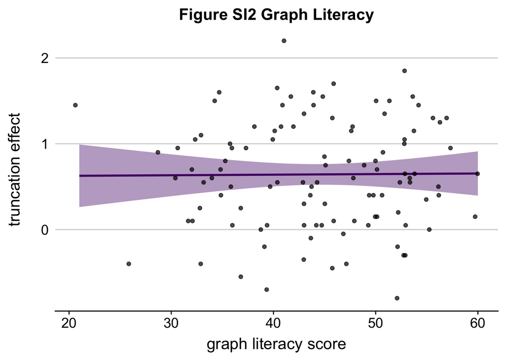

#### Education (Supplemental Information)

Education Anova

```
##              Df Sum Sq Mean Sq F value Pr(>F)
## dem_ed        7   3.90  0.5571   1.442  0.197
## Residuals   101  39.02  0.3863
```

Education and graph literacy

```
##
## Call:
## lm(formula = graphliteracy_sum_rating ~ dem_ed, data = models_difference_df)
##
## Residuals:
##      Min       1Q   Median       3Q      Max
## -21.1999  -6.3495   0.6505   5.6505  15.0337
##
## Coefficients:
##             Estimate Std. Error t value             Pr(>|t|)
## (Intercept)  38.0503     2.1242  17.912 < 0.0000000000000002 ***
## dem_ed        1.3832     0.4285   3.228              0.00165 **
## ---
## Signif. codes:  0 '***' 0.001 '**' 0.01 '*' 0.05 '.' 0.1 ' ' 1
##
## Residual standard error: 7.893 on 107 degrees of freedom
## Multiple R-squared:  0.08875,    Adjusted R-squared:  0.08023
## F-statistic: 10.42 on 1 and 107 DF,  p-value: 0.001654
```

#### Age (Supplemental Information)

Age Linear Regression

```
##
## Call:
## lm(formula = difference ~ dem_age, data = models_difference_df)
##
## Residuals:
##      Min       1Q   Median       3Q      Max
## -1.44674 -0.50075 -0.02971  0.50426  1.54925
##
## Coefficients:
##              Estimate Std. Error t value Pr(>|t|)
## (Intercept)  0.677791   0.200412   3.382  0.00101 **
## dem_age     -0.001002   0.005446  -0.184  0.85443
## ---
## Signif. codes:  0 '***' 0.001 '**' 0.01 '*' 0.05 '.' 0.1 ' ' 1
##
## Residual standard error: 0.6332 on 107 degrees of freedom
## Multiple R-squared:  0.000316,   Adjusted R-squared:  -0.009027
## F-statistic: 0.03382 on 1 and 107 DF,  p-value: 0.8544
```

Figure depicts this age null relationship.

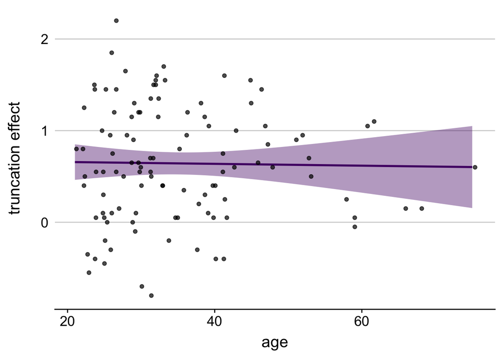

#### Item Analysis (Supplemental Information)

Here we summarise the data for each item. This is helpful to identify if the effect is driven by a few graphs or if it is seen across all graphs in the materials.

| condition | n | mean | sd | median | min | max | range |
| --- | --- | --- | --- | --- | --- | --- | --- |
| control | 40 | 3.636793 | 1.260341 | 3.327273 | 1.381818 | 6.236364 | 4.854545 |
| truncated | 40 | 4.280850 | 1.198725 | 4.345455 | 1.888889 | 6.203704 | 4.314815 |

| question | control | truncated | diff |
| --- | --- | --- | --- |
| 1 | 3.000000 | 3.777778 | 0.77777778 |
| 2 | 4.296296 | 4.781818 | 0.48552189 |
| 3 | 2.018182 | 3.240741 | 1.22255892 |
| 4 | 4.611111 | 5.472727 | 0.86161616 |
| 5 | 4.363636 | 5.203704 | 0.84006734 |
| 6 | 3.240741 | 3.781818 | 0.54107744 |
| 7 | 4.000000 | 5.148148 | 1.14814815 |
| 8 | 2.796296 | 3.472727 | 0.67643098 |
| 9 | 3.272727 | 3.962963 | 0.69023569 |
| 10 | 2.185185 | 2.872727 | 0.68754209 |

[output cut: 30 more lines]

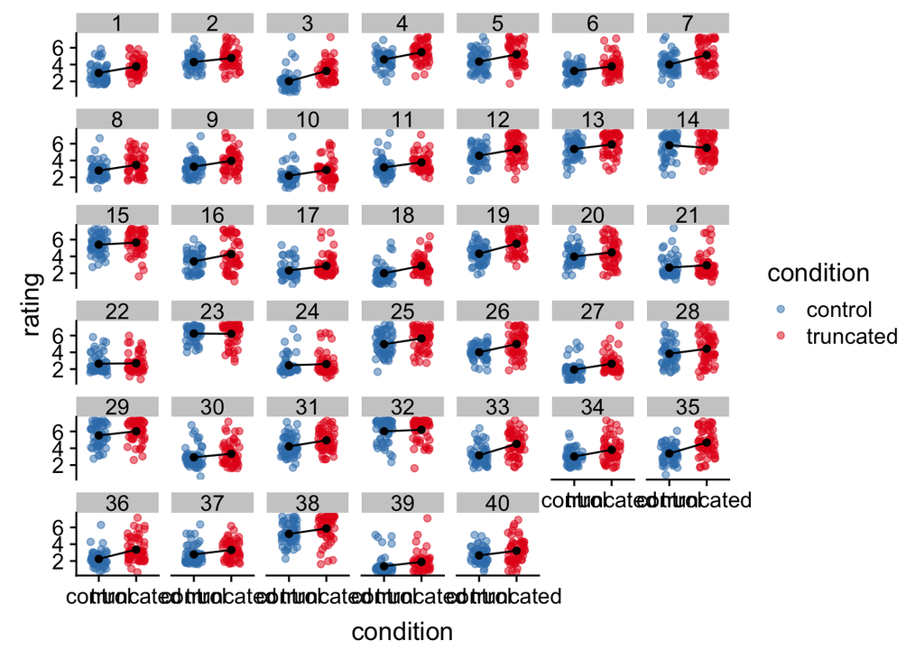

| question | control | truncated | diff |
| --- | --- | --- | --- |
| 14 | 5.814815 | 5.509091 | -0.30572391 |
| 23 | 6.236364 | 6.203704 | -0.03265993 |

| n | mean | sd | median | min | max | range |
| --- | --- | --- | --- | --- | --- | --- |
| 40 | 0.6440572 | 0.3623417 | 0.663468 | 0.03265993 | 1.354882 | 1.322222 |

The truncation effect was observed for all graphs except graph 14, 23. On average, the 7-point ratings were 0.64 (SD = 0.36) higher when graphs were seen in the truncated condition than when they were seen in the control condition. The maximum average absolute difference between the trunccted and control conditions was for graph 33 M = 1.35 The minimum average absolute difference was for graph 23 where M = 0.03.

#### Timing (Supplemental Information)

Timing information is in seconds.

You can choose to trim or not timing data. By default any timing that is 2 standard deviations away from the mean (for each participant for each condition) is trimmed.

For this report, any timing that is 2 standard deviations away from the mean (for each participant for each condition) WAS trimmed. If you want to see results when participants who got the exercise wrong are excluded/included, you can go to the section called Exclusions (at the top of this file) and change Trimming <- FALSE

| condition | n | mean | sd | median | min | max | range |
| --- | --- | --- | --- | --- | --- | --- | --- |
| control | 109 | 12.17737 | 8.406428 | 10.29989 | 0.3631579 | 48.56963 | 48.20647 |
| truncated | 109 | 11.74401 | 6.994337 | 10.90160 | 0.5535789 | 40.13956 | 39.58598 |

Item Analysis for Timing

| condition | n | mean | sd | median | min | max | range |
| --- | --- | --- | --- | --- | --- | --- | --- |
| control | 40 | 12.2293 | 2.514846 | 11.58732 | 8.383208 | 20.31104 | 11.927836 |
| truncated | 40 | 11.7604 | 1.715716 | 11.88163 | 8.642058 | 17.83709 | 9.195037 |

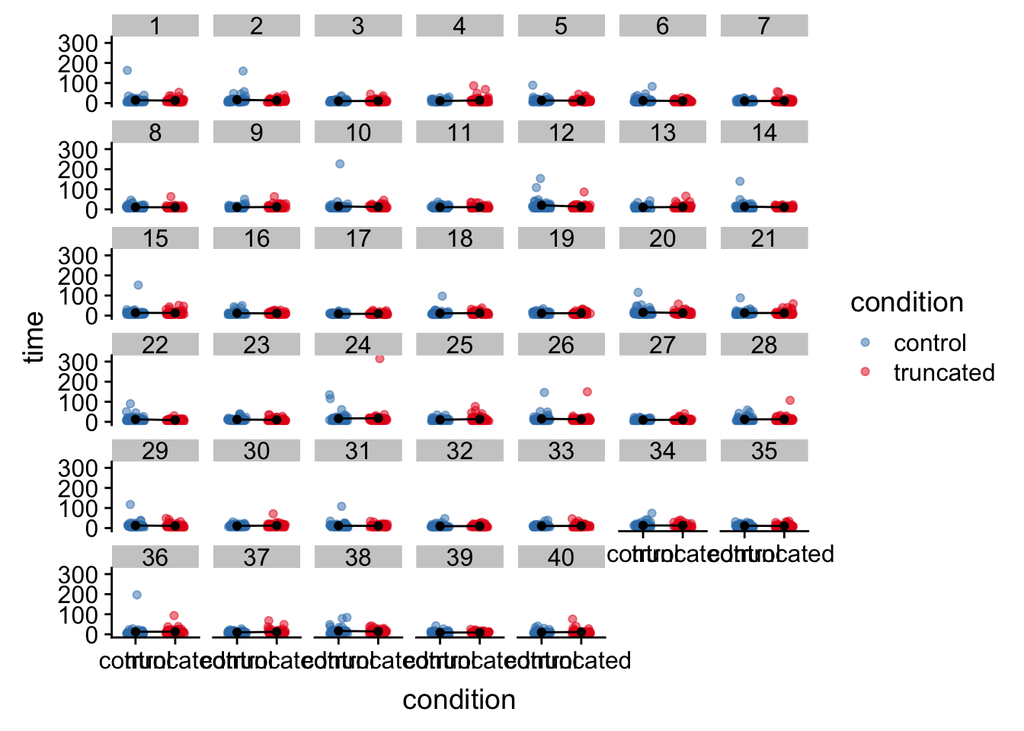